# Lab 8: Factorial ANOVA

# Purpose

Factorial ANOVA refers to a special case of the general linear model in which there is an interaction of two or more categorical variables (i.e. *factors*). A factorial design is used when there is an interest in how two or more variables (or factors) affect some outcomes variable. Rather than conduct separate one-way ANOVAs for each factor, they are all included in one analysis. Today we will review how to run factorial ANOVA models in R and how to interpret and visualize the results.

1. Research scenario
2. Tables of means
3. Running the model
4. Plotting
5. Simple effects

Be sure to have the following packages installed and loaded:

```r
library(tidyverse) # for plotting and data wrangling
library(rio) # for importing data
library(psych) # for descriptives
library(lsr) # for eta squared functions
library(emmeans) # for marginal means and simple effects
library(sjPlot) # for plotting model results
library(ggpubr) # for arranging plots
library(apaTables) # for tables of means
library(car) # for testing model assumptions
library(broom) # for tidying model output
```

# Research scenario

- Based on subjects’ self-reports of rejection sensitivity (N = 80), a researcher divides subjects into two equal groups (low RS and high RS). Whereas half of the subjects in each group interact with a partner who displays a happy emotional expression during the interaction, the other half of the subjects in each group interact with a partner who displays a neutral emotional expression during the interaction. After the interaction, subjects are asked to rate the statement, “My interaction partner likes me”, on a scale from 1 (strongly disagree) to 7 (strongly agree).

> **Question:** What type of factorial ANOVA design is this?

> **Answer:** This represents a 2 x 2 factorial ANOVA.

## Data

- Import the data

```r
reject <- import("https://raw.githubusercontent.com/uopsych/psy612/master/labs/lab-8/data/reject.csv")
```

- Check out the data

##### Code

```r
str(reject)
```

##### Output

```
## 'data.frame':    80 obs. of  3 variables:
##  $ rs     : chr  "Low" "Low" "Low" "Low" ...
##  $ partner: chr  "Neutral" "Neutral" "Neutral" "Neutral" ...
##  $ liking : int  4 4 4 5 5 5 5 5 5 5 ...
```

- Look at the first few rows

##### Code

```r
head(reject)
```

##### Output

|  | rs | partner | liking |
| --- | --- | --- | --- |
| 1 | Low | Neutral | 4 |
| 2 | Low | Neutral | 4 |
| 3 | Low | Neutral | 4 |
| 4 | Low | Neutral | 5 |
| 5 | Low | Neutral | 5 |
| 6 | Low | Neutral | 5 |

- It looks like `rs` and `partner` are both being read in as character variables. Let’s go ahead and change those to factors.

```r
reject <- reject %>%
  mutate(rs = as.factor(rs),
         partner = as.factor(partner))
```

- Check the structure again. Notice that by default R orders factor levels alphabetically. In our case, this means that `High` will be the reference group of rejection sensitivity and `Happy` will be the reference group of interaction partner’s emotional expression. However, it might be more intuitive to have `Low` and `Neutral` be the reference groups, respectively.

##### Code

```r
str(reject)
```

##### Output

```
## 'data.frame':    80 obs. of  3 variables:
##  $ rs     : Factor w/ 2 levels "High","Low": 2 2 2 2 2 2 2 2 2 2 ...
##  $ partner: Factor w/ 2 levels "Happy","Neutral": 2 2 2 2 2 2 2 2 2 2 ...
##  $ liking : int  4 4 4 5 5 5 5 5 5 5 ...
```

- To accomplish this, we can simply re-order the levels of our factor variables with `fct_relevel()`.

```r
# manually specify order of factor levels
reject <- reject %>%
  mutate(rs = fct_relevel(rs, c("Low", "High")),
         partner = fct_relevel(partner, c("Neutral", "Happy")))
```

- To make sure this work, check the structure again.

##### Code

```r
str(reject)
```

##### Output

```
## 'data.frame':    80 obs. of  3 variables:
##  $ rs     : Factor w/ 2 levels "Low","High": 1 1 1 1 1 1 1 1 1 1 ...
##  $ partner: Factor w/ 2 levels "Neutral","Happy": 1 1 1 1 1 1 1 1 1 1 ...
##  $ liking : int  4 4 4 5 5 5 5 5 5 5 ...
```

- Do we have a balanced design?

##### Code

```r
reject %>%
  group_by(rs, partner) %>%
  summarize(n = n())
```

##### Output

| rs | partner | n |
| --- | --- | --- |
| Low | Neutral | 20 |
| Low | Happy | 20 |
| High | Neutral | 20 |
| High | Happy | 20 |

# Tables of means

## Using `summarize()`

- We’ll create 4 tables of means:
1. cell means (i.e., for each combination of the two factors)
2. marginal means for interaction partner (averaged across levels of rejection sensitivity)
3. marginal means for RS (averaged across levels of interaction partner)
4. grand mean (averaged across both rejection sensitivity and interaction partner)

### Cell Means

##### Code

```r
reject %>%
  group_by(rs, partner) %>%
  summarize(mean = mean(liking, na.rm = TRUE),
            sd = sd(liking, na.rm = TRUE)) %>%
knitr::kable(digits = c(NA, NA, 2, 2, 2),
             caption = "Cell Means & SD")
```

##### Output

Cell Means & SD

| rs | partner | mean | sd |
| --- | --- | --- | --- |
| Low | Neutral | 5.55 | 1.05 |
| Low | Happy | 6.00 | 0.73 |
| High | Neutral | 1.80 | 0.70 |
| High | Happy | 6.45 | 0.69 |

### Marginal Means: Interaction Partner

##### Code

```r
reject %>%
  group_by(partner) %>% # instead of grouping by both factors, we just group by interaction partner
  summarize(mean = mean(liking, na.rm = TRUE),
            sd = sd(liking, na.rm = TRUE)) %>%
knitr::kable(digits = c(NA, 2, 2, 2),
             caption = "Marginal Means & SD for Interaction Partner")
```

##### Output

Marginal Means & SD for Interaction Partner

| partner | mean | sd |
| --- | --- | --- |
| Neutral | 3.67 | 2.09 |
| Happy | 6.22 | 0.73 |

### Marginal Means: Rejection Sensitivity

##### Code

```r
reject %>%
  group_by(rs) %>% # just group by rs for this one
  summarize(mean = mean(liking, na.rm = TRUE),
            sd = sd(liking, na.rm = TRUE)) %>%
knitr::kable(digits = c(NA, 2, 2, 2),
             caption = "Marginal Means & SD for Rejection Sensitivity")
```

##### Output

Marginal Means & SD for Rejection Sensitivity

| rs | mean | sd |
| --- | --- | --- |
| Low | 5.78 | 0.92 |
| High | 4.12 | 2.45 |

### Grand Mean

##### Code

```r
reject %>% # note that we don't need group_by for this one
  summarize(mean = mean(liking, na.rm = TRUE),
            sd = sd(liking, na.rm = TRUE)) %>%
knitr::kable(digits = c(2, 2, 2),
             caption = "Grand Mean")
```

##### Output

Grand Mean

| mean | sd |
| --- | --- |
| 4.95 | 2.02 |

## An easier way

- The `apa.2way.table()` function from `{apaTables}` is a much more convenient way to get our cell means and marginal means. This function works for any type of 2-way ANOVA, regardless of the number of levels of your factors, e.g. it would work for a 3 x 3 ANOVA. All you need to do is indicate what the IV’s and DV are and specify `show.marginal.means = TRUE`.

##### Code

```r
apa.2way.table(iv1 = rs,
               iv2 = partner,
               dv = liking,
               data = reject,
               show.marginal.means = TRUE)
```

##### Output

```
##
##
## Means and standard deviations for liking as a function of a 2(rs) X 2(partner) design
##
##           partner
##           Neutral      Happy      Marginal
##        rs       M   SD     M   SD        M   SD
##       Low    5.55 1.05  6.00 0.73     5.78 0.92
##      High    1.80 0.70  6.45 0.69     4.12 2.45
##  Marginal    3.67 2.09  6.22 0.73
##
## Note. M and SD represent mean and standard deviation, respectively.
## Marginal indicates the means and standard deviations pertaining to main effects.
```

- An added plus is that you can easily export these tables to word (see `?apa.2way.table`).

##### Code

```r
apa.2way.table(iv1 = rs,
               iv2 = partner,
               dv = liking,
               data = reject,
               show.marginal.means = TRUE,
               table.number = 1,
               filename = here::here("/labs/lab-8/images/means.doc")) # example file path
```

##### Output

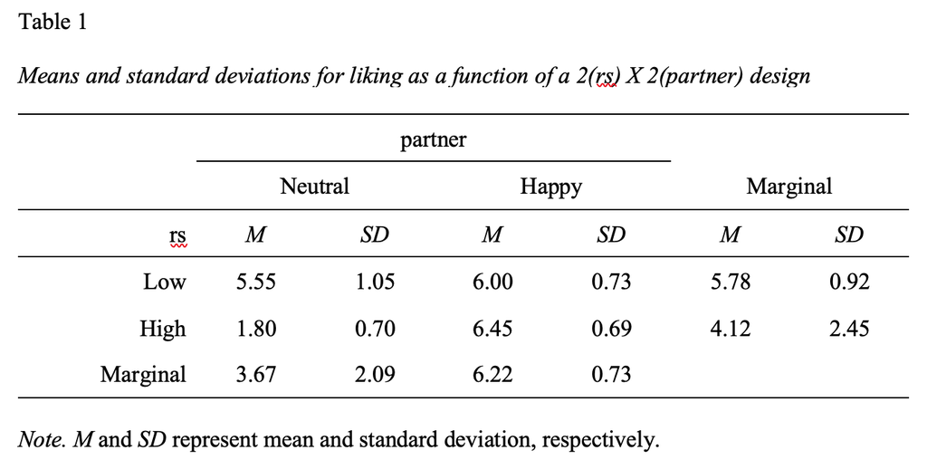

- Remember, a **main effect** is the effect of one IV on the DV completely ignoring the other variable(s).

> **Question:** Which means are being compared in the main effect of rejection sensitivity?

> **Answer:** marginal means for low (5.78) and high (4.13) levels of rejection sensitivity

> **Question:** Which means are being compared in the main effect of interaction partner?

> **Answer:** Marginal means for neutral partner (3.68) and happy partner (6.22)

> **Question:** Which means are involved in the interaction?

> **Answer:** the cell means

# Running the model

```r
model <- lm(liking ~ rs * partner, data = reject)
```

- We can look at the regression coefficients from the model. However, in the case of factorial ANOVA, these are less useful to interpret.

##### Code

```r
summary(model)
```

##### Output

```
##
## Call:
## lm(formula = liking ~ rs * partner, data = reject)
##
## Residuals:
##    Min     1Q Median     3Q    Max
##  -1.55  -0.55   0.00   0.55   1.45
##
## Coefficients:
##                     Estimate Std. Error t value            Pr(>|t|)
## (Intercept)           5.5500     0.1797   30.88 <0.0000000000000002 ***
## rsHigh               -3.7500     0.2542  -14.75 <0.0000000000000002 ***
## partnerHappy          0.4500     0.2542    1.77              0.0807 .
## rsHigh:partnerHappy   4.2000     0.3595   11.68 <0.0000000000000002 ***
## ---
## Signif. codes:  0 '***' 0.001 '**' 0.01 '*' 0.05 '.' 0.1 ' ' 1
##
## Residual standard error: 0.8038 on 76 degrees of freedom
## Multiple R-squared:  0.8474, Adjusted R-squared:  0.8414
## F-statistic: 140.7 on 3 and 76 DF,  p-value: < 0.00000000000000022
```

## ANOVA table

- Instead, we will focus on the ANOVA table output. We can get this using `anova()`.

##### Code

```r
anova(model)
```

##### Output

|  | Df | Sum Sq | Mean Sq | F value | Pr(>F) |
| --- | --- | --- | --- | --- | --- |
| rs | 1 | 54.45 | 54.4500000 | 84.28106 | 0.00000000000006028183751851767 |
| partner | 1 | 130.05 | 130.0500000 | 201.29939 | 0.00000000000000000000004639143 |
| rs:partner | 1 | 88.20 | 88.2000000 | 136.52138 | 0.00000000000000000120996923390 |
| Residuals | 76 | 49.10 | 0.6460526 | NA | NA |

> **Question:** Is there a main effect of rejection sensitivity on perceived liking?

> **Answer:** Yes, BUT it depends on the interaction partner

> **Question:** Is there a main effect of interaction partner on perceived liking?

> **Answer:** Yes, BUT it depends on the perceiver’s rejection sensitivity

> **Question:** Is there an interaction between rejection sensitivity and interaction partner?

> **Answer:** Yes
- We can tidy the ANOVA table output with `broom::tidy()`

##### Code

```r
anova(model) %>%
  broom::tidy()
```

##### Output

| term | df | sumsq | meansq | statistic | p.value |
| --- | --- | --- | --- | --- | --- |
| rs | 1 | 54.45 | 54.4500000 | 84.28106 | 0.00000000000006028183751851767 |
| partner | 1 | 130.05 | 130.0500000 | 201.29939 | 0.00000000000000000000004639143 |
| rs:partner | 1 | 88.20 | 88.2000000 | 136.52138 | 0.00000000000000000120996923390 |
| Residuals | 76 | 49.10 | 0.6460526 | NA | NA |

- `apaTables::apa.aov.table()` will generate an APA-formatted comprehensive ANOVA table for you

##### Code

```r
# might need to have the {MBESS} package installed to use this function
# install.packages("MBESS")

apa.aov.table(lm_output = model,
              conf.level = .95)
```

##### Output

```
##
##
## ANOVA results using liking as the dependent variable
##
##
##     Predictor     SS df     MS      F    p partial_eta2 CI_95_partial_eta2
##   (Intercept) 616.05  1 616.05 953.56 .000
##            rs 140.62  1 140.62 217.67 .000          .74         [.64, .80]
##       partner   2.03  1   2.03   3.13 .081          .04         [.00, .15]
##  rs x partner  88.20  1  88.20 136.52 .000          .64         [.51, .73]
##         Error  49.10 76   0.65
##
## Note: Values in square brackets indicate the bounds of the 95% confidence interval for partial eta-squared
```

- This also allows you to output tables to Word.

##### Code

```r
apa.aov.table(lm_output = model,
              conf.level = .95,
              table.number = 2,
              filename = here::here("/labs/lab-8/images/anova_table.doc"))
```

##### Output

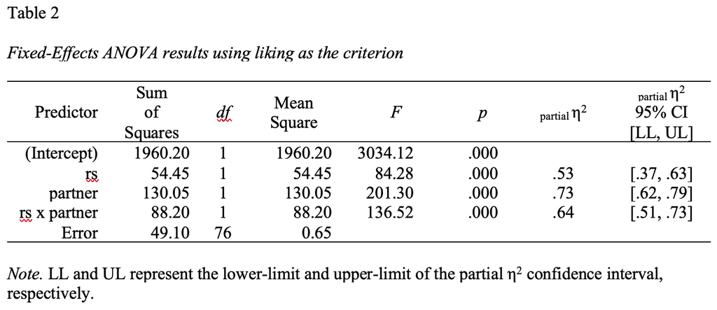

## Checking assumptions

- You can check the assumptions of the factorial ANOVA in much the same way you check them for multiple regression; but given the categorical nature of the predictors, some assumptions are easier to check.
- Homogeneity of variance, for example, can be tested using Levene’s test, instead of examining a plot.

##### Code

```r
car::leveneTest(liking ~ rs * partner, data = reject)
```

##### Output

|  | Df | F value | Pr(>F) |
| --- | --- | --- | --- |
| group | 3 | 1.367196 | 0.2592311 |
|  | 76 | NA | NA |

> **Question:** Have we met the homogeneity of variance assumption?

> **Answer:** Yes

## Effect size

- All of the effects in the ANOVA are statistically significant, but how big are they? An effect size, $\eta^2$, provides a simple way of indexing effect magnitude for ANOVA designs. You can think of it the same way as $R^2$ (proportion of variance explained).
- To calculate $\eta^2$, we’ll use `etaSquared` from `{lsr}` (the companion package to your textbook).

##### Code

```r
lsr::etaSquared(model)
```

##### Output

```
##               eta.sq eta.sq.part
## rs         0.1692045   0.5258329
## partner    0.4041330   0.7259280
## rs:partner 0.2740833   0.6423889
```

> **Question:** What does partial eta squared represent? Why might be prefer partial eta squared over eta squared?

> **Answer:** One argument against eta squared is that its magnitude depends in part on the magnitude of the other effects in the design. Partial eta squared pretends the other effects do not exist, comparing only to residual variability.

# Plotting

## Main effects

##### Code

```r
# main effect of rejection sensitivity
rs_plot <- plot_model(model, type = "pred", terms = c("rs"))

# main effect of interaction partner
partner_plot <- plot_model(model, type = "pred", terms = c("partner"))

# arrange these two plots next to each other
ggpubr::ggarrange(rs_plot, partner_plot, ncol = 2)
```

##### Output

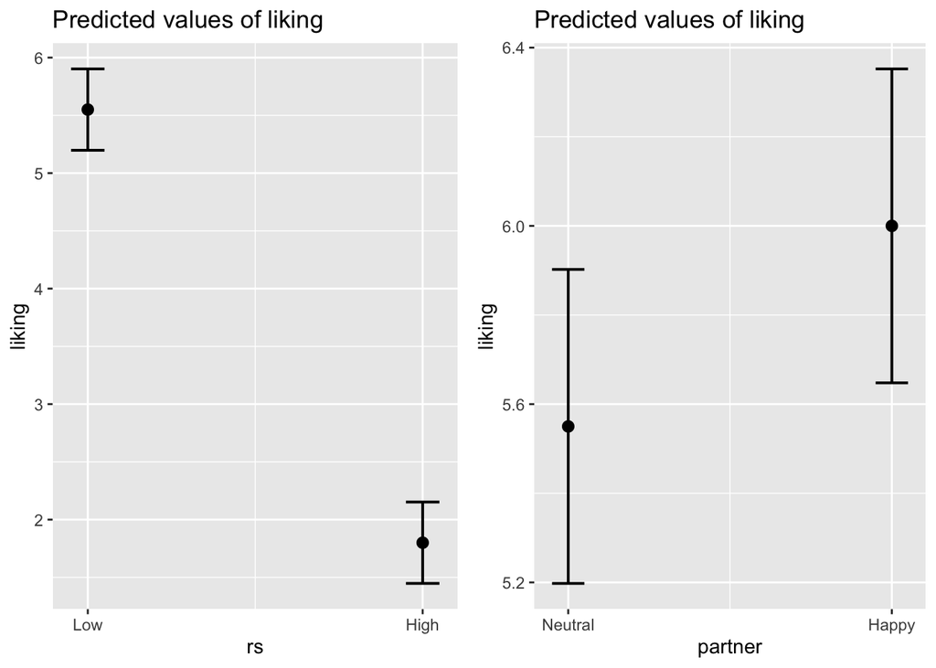

## Interaction

##### Code

```r
# plot the interaction
plot_model(model, type = "int")
```

##### Output

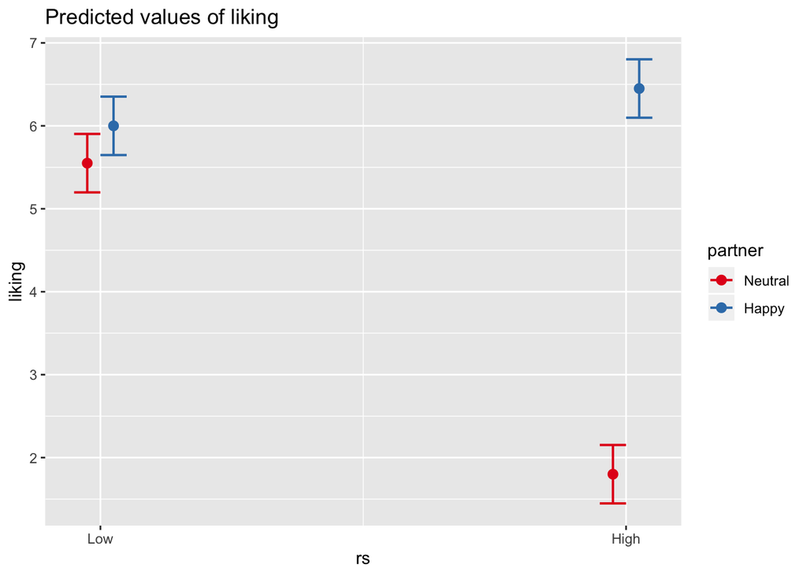

- Switch how the interaction is visualized

##### Code

```r
# switch the order of the terms
plot_model(model, type = "pred", terms = c("partner", "rs"))
```

##### Output

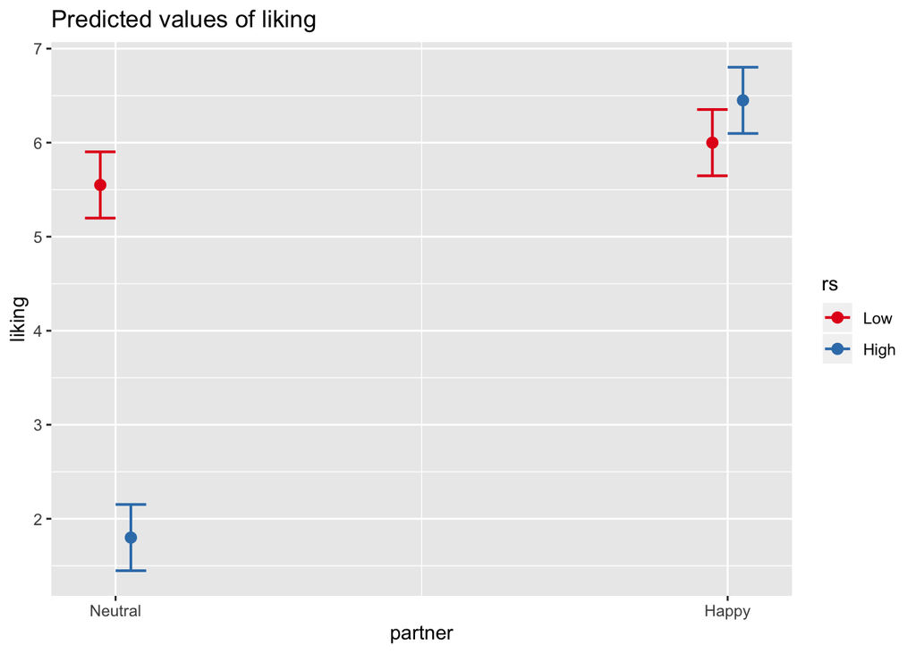

- The following ggplot code will generate a bar plot version of the interaction plot. The `emmeans()` function at the beginning calculates cell means (more on this below).

##### Code

```r
emmeans(model, specs = c("partner", "rs")) %>%
  broom::tidy() %>%
  ggplot(aes(x = rs, y = estimate, fill = partner)) +
  geom_bar(stat = "identity",
           position = "dodge",
           alpha = 0.7) +
  geom_errorbar(aes(ymin = conf.low, ymax = conf.high),
                width = 0.20,
                position = position_dodge(0.9)) +
  labs(title = "Effects of Rejection Sensitivity and Interaction Partner Expression \non Perceived Liking",
       x = "Rejection Sensitivity",
       y = "Perceived liking") +
  guides(fill=guide_legend(title = "Partner's Expression")) +
  theme_minimal()
```

##### Output

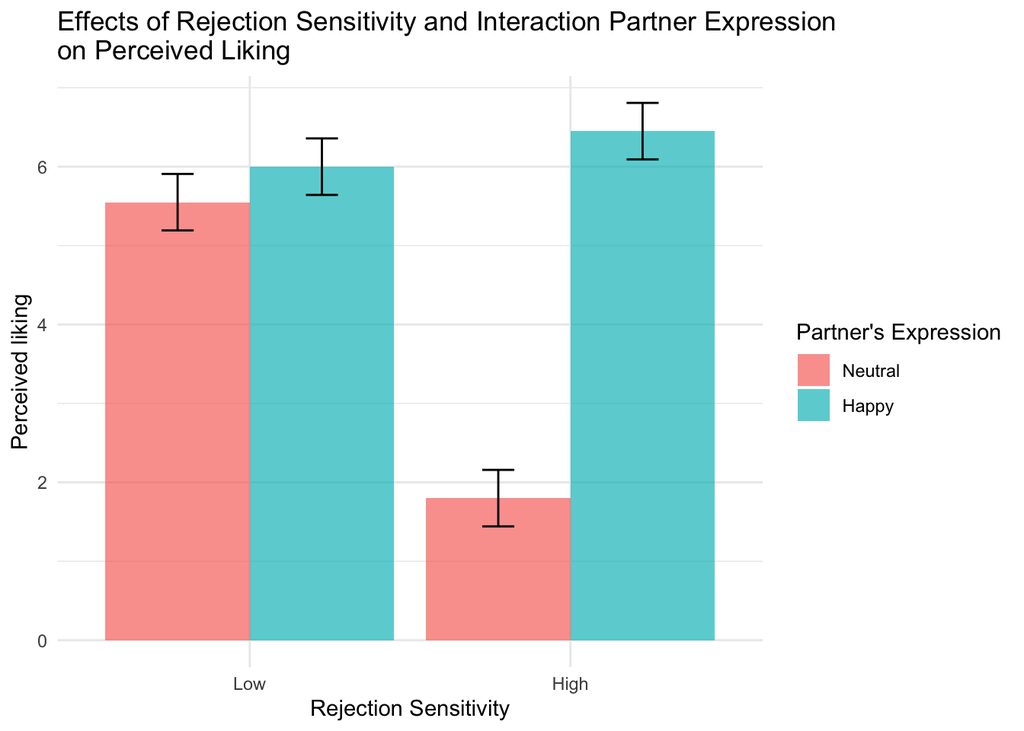

# Simple effects

- Since we had a significant interaction above, we should look at the simple effects. Recall that simple effects are the effect of some factor (e.g., interaction partner’s expression) at each level of another factor (e.g., at high and low RS separately).
- We’ll look at the simple effect of interaction partner having a neutral vs. happy expression on perceived liking at different levels of rejection sensitivity. We’ll use the `{emmeans}` package, which Sara will go over more in lecture next week.
- To get simple effects, we combine the `emmeans()` function with the `contrast()` function (both from `{emmeans}`). `emmeans()` works by passing it a model and then specifying which variables you’re looking at. Then, we pass that along to `contrast()`, which can give us a variety of different contrasts. If we want simple effects for interaction partner expression at each level of rejection sensitivity we can use `by = "rs"` and `simple = "partner"`.

##### Code

```r
model %>% emmeans(specs = c("partner", "rs")) %>% # specify our two factors
  contrast(by = "rs", # by is the variable we are looking at each level of
           simple = "partner") # simple is what we want simple effects of.
```

##### Output

```
## rs = Low:
##  contrast       estimate    SE df t.ratio p.value
##  Neutral effect   -0.225 0.127 76  -1.770 0.0807
##  Happy effect      0.225 0.127 76   1.770 0.0807
##
## rs = High:
##  contrast       estimate    SE df t.ratio p.value
##  Neutral effect   -2.325 0.127 76 -18.294 <.0001
##  Happy effect      2.325 0.127 76  18.294 <.0001
##
## P value adjustment: fdr method for 2 tests
```

- The output has two lines per simple effect, which just shows you what it looks like in either direction (note that they are equivalent), so you would just pick the direction that makes the most sense.